# Neurofeedback training of spatial and feature-based attention: Statistical analysis

Angela I. Renton

## Setup

```r
# Import packages
library(BayesFactor)
library(tidyverse)
library(ggplot2)
library("rjags")

# Set seed
set.seed(82)
```

## Overview

The past decade has witnessed a dramatic rise in “decoded” neurofeedback protocols, which aim to train multivariate patterns of neural activity with the aim of investigating and enhancing cognitive function. These protocols establish real-time feedback loops, directly translating decoded patterns of neural activity into sensory feedback with the aim of training participants to regulate specific cognitive processes. The advent of implicit neurofeedback protocols, in which participants are unaware of the target of neurofeedback training, has allowed decoded neurofeedback protocols to gain popularity as a causal research method. Implicit neurofeedback paradigms rule out placebo effects and likely result in training specific to the targeted pattern of neural activity. However, interpreting the results of such studies requires a better understanding of the degree to which decoded patterns of neural activity may represent unaccounted-for cognitive processes which merely correlate with the target. Here, we investigated whether decoded neurofeedback could be applied to enhance spatial and feature-based selective attention and tested the cognitive specificity of such training by evaluating whether any training effects transferred to the untrained attentional property.

## Statistical Methods

### Statement on statistical approach

Our primary objective in developing the statistical approach used in this study was to convey a clear, thorough and intuitive picture of the nature of the effects of neurofeedback training on our neural and behavioural measures. As such, we chose to report Bayes Factors representing the ratio of evidence in favour of the alternative vs. null hypothesis for each of our effects of interest. Bayes Factors were interpreted according to Jeffrey’s criterion:

Jarosz, A. F., & Wiley, J. (2014). What are the odds? A practical guide to computing and reporting Bayes factors. *The Journal of Problem Solving*, *7*(1), 2. doi: 10.7771/1932-6246.1167

| Bayes Factor | Inverse of Bayes Factor | Support for H1 |
| --- | --- | --- |
| 1 - .33 | 1 - 3 | Anecdotal |
| .33 - .10 | 3 - 10 | Substantial |
| .10 - .03 | 10 - 30 | Strong |
| .03 - .01 | 30 - 100 | Very Strong |
| <.01 | >100 | Decisive |

This approach was outlined thoroughly in the pre-registration document for this study: https://osf.io/q4whu/.

### JZS t-tests

When evaluating whether or not any two groups shared the same mean on any measure of interest, we applied a Bayesian “JZS” t-test, as outlined here:

Rouder, J. N., Speckman, P. L., Sun, D., Morey, R. D., & Iverson, G. (2009). Bayesian t tests for accepting and rejecting the null hypothesis. *Psychonomic Bulletin & Review*, *16*(2), 225–237. doi: 10.3758/PBR.16.2.225

### Bayesian ANOVAs

When evaluating whether or not the levels of our experimental factors affected any measure of interest (main effects) or interacted with each other (interactions) we applied the Bayesian ANOVA approach outlined here:

Rouder, J. N., Morey, R. D., Speckman, P. L., & Province, J. M. (2012). Default Bayes factors for ANOVA designs. *Journal of mathematical psychology*, *56*(5), 356-374.

In line with the recommendations of Rouder et al. (2012), bayes factors for main effects and interactions in Bayesian ANOVA models were assessed by comparing the full model (main effects + interaction + random effects) with the model containing all effects bar the effect of interest.

We’ll use this function to run and reports the results of 2x2 Bayesian ANOVAs below:

```r
DisplayANOVAResults2X2 <- function(formula, data, maineffectstringA, maineffectstringB) {
  # Run ANOVA
  bf = anovaBF(formula , data=data, whichRandom="SubID",  whichModels="all")

  # extract effects of interest
  bfInteraction = bf[7]/bf[4] # is the full model better than just strait main effects?
  bf_main_A = bf[7]/bf[5] # is the full model better than the main effect A knock out?
  bf_main_B = bf[7]/bf[6] # is the full model better than the main effect B knock out?

  # display results
  print(bf)
  cat('\n\nInteraction:\n\n')
  print(bfInteraction)

  cat(paste('\n\n', maineffectstringA, '\n\n'))
  print(bf_main_A)

  cat(paste('\n\n', maineffectstringB, '\n\n'))
  print(bf_main_B)

}
```

### Markov Chain Monte-Carlo (MCMC) Gibbs Sampling

Bayes Factors represent the ratio of evidence in favour of the alternative vs. null hypothesis; which may be more intuitive to readers than frequentist statistics. Bayesian methods rely on modelling the posterior distribution of effects in the population using the data in combination with informed priors for the effect of interest. Plotting these posterior distributions allows us to visualise our beliefs about how neurofeedback would effect our measures of interest in the population, and calculate the posterior probabilities for specific effects. To this end, we applied a Markov Chain Monte-Carlo Gibbs sampling approach to visualise the posteriors over each or our measures, as described here:

van Ravenzwaaij, D., Cassey, P. & Brown, S.D. A simple introduction to Markov Chain Monte–Carlo sampling. *Psychon Bull Rev* **25**, 143–154 (2018). doi: 10.3758/s13423-016-1015-8

I recommend this article for a practicle tutorial and description of the benefits of this approach: https://medium.com/swlh/bayesian-analysis-based-on-mcmc-gibbs-algorithm-d5b0cfd5e2dd

## Evaluating Training Efficacy

### Representational Similarity Analysis (RSA)

#### Methodological background

We measured the efficacy of neurofeedback at altering multidimensional neural activity by applying a representational similarity analysis (RSA) approach; quantifying the dissimilarity between the patterns of neural activity evoked by pre- and post-training attention tests. RSA applies a correlational approach to characterise high-dimensional neural responses within a low-dimensional embedding known as a representational dissimilarity matrix (RDM). To implement this analysis, we followed the method outlined here:

Kriegeskorte, N., Mur, M., & Bandettini, P. A. (2008). Representational similarity analysis-connecting the branches of systems neuroscience. *Frontiers in systems neuroscience*, 4. doi: 10.3389/neuro.06.004.2008F

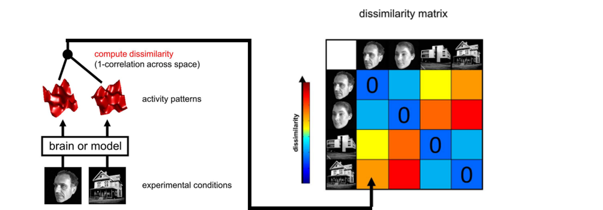

**Figure 1. Computation of the representational dissimilarity matrix (adapted from Kriegeskorte et al. (2008)).** For each pair of experimental conditions, the associated activity patterns (in a brain region or model) are compared by spatial correlation. The dissimilarity between them is measured as 1 minus the correlation (0 for perfect correlation, 1 for no correlation, 2 for perfect anticorrelation). These dissimilarities for all pairs of conditions are assembled in the RDM. Each cell of the RDM, thus, compares the response patterns elicited by two images. As a consequence, an RDM is symmetric about a diagonal of zeros.

#### Load Data

We begin by loading in the RSA results. These data show the bootstrapped representational dissimilarity from before to after neurofeedback training for each neurofeedback group (Space, Feature, Sham).

We’ll add a new factor (“NFTraining”) with two just two levels (Neurofeedback, Sham), so that we have the option to evaluate the effect of getting active neurofeedback , regardless of what type of attention the feedback represented.

```r
# load data
RSAdata = read.csv("//data.qbi.uq.edu.au/VISATTNNF-Q1357/Results/CompareSpaceFeat/group/RSA_results.csv")

# factorise existing factors
RSAdata$Bootstrap = factor(RSAdata$Bootstrap)
RSAdata$TrainingGroup = factor(RSAdata$TrainingGroup, levels=c("Space", "Feature", "Sham"))

# Create NFTraining factor
RSAdata$NFTraining = RSAdata$TrainingGroup
levels(RSAdata$NFTraining) = c( "Neurofeedback","Neurofeedback", "Sham")

# Show table data in markdown output
data <- RSAdata[1:10, ]
knitr::kable(data, caption = "Sample of RSA Data")
```

Sample of RSA Data

| TrainingGroup | Bootstrap | RDM_Score | NFTraining |
| --- | --- | --- | --- |
| Space | 0 | 0.2596557 | Neurofeedback |
| Space | 1 | 0.2450191 | Neurofeedback |
| Space | 2 | 0.2667993 | Neurofeedback |
| Space | 3 | 0.2539360 | Neurofeedback |
| Space | 4 | 0.2379879 | Neurofeedback |
| Space | 5 | 0.2281404 | Neurofeedback |
| Space | 6 | 0.2552607 | Neurofeedback |
| Space | 7 | 0.2992153 | Neurofeedback |
| Space | 8 | 0.2539057 | Neurofeedback |
| Space | 9 | 0.2706544 | Neurofeedback |

Before we proceed, lets visualise these data.

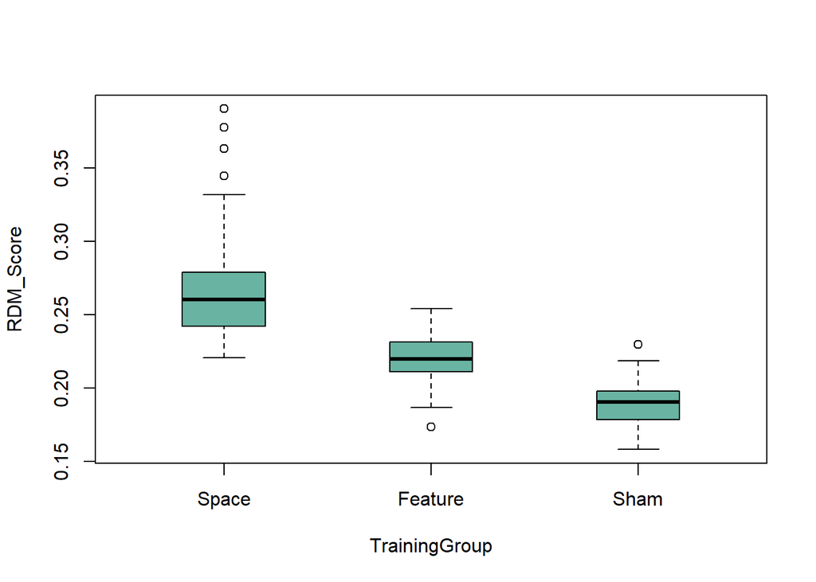

```r
boxplot(RDM_Score ~ TrainingGroup, col="#69b3a2", boxwex=0.4, data=RSAdata)
```

#### Main effect of training type

First, we evaluate whether there is a main effect of neurofeedback training group (Space, Feature, Sham) on representational dissimilarity. E.g. did the type of neurofeedback that participants received affect how much they shifted their patterns of neural activity in respone to the attention task over the course of training?

```r
bf = anovaBF(RDM_Score ~ TrainingGroup , data=RSAdata, whichRandom="bootstrap",  whichModels="all")
print(bf)
```

```
## Bayes factor analysis
## --------------
## [1] TrainingGroup : 9.51185e+67 ±0%
##
## Against denominator:
##   Intercept only
## ---
## Bayes factor type: BFlinearModel, JZS
```

We find decisive evidence for a main effect of training group. Specifically, there is much more evidence for models in which our representational dissimilarity data varies according to neurofeedback type, than for models without this main effect. We’ll follow this main effect up by evaluating how each of our two active neurofeedback groups compared to the sham group.

#### Follow-up JZS t-tests

Firstly, how did the space training group compare to the sham group?

```r
datuse = RSAdata[RSAdata$TrainingGroup == "Space" | RSAdata$TrainingGroup == "Sham",]
datuse$TrainingGroup = factor(datuse$TrainingGroup)
print(ttestBF(formula = RDM_Score ~ TrainingGroup, data=datuse))
```

```
## t is large; approximation invoked.
```

```
## Bayes factor analysis
## --------------
## [1] Alt., r=0.707 : 5.052701e+49 ±0%
##
## Against denominator:
##   Null, mu1-mu2 = 0
## ---
## Bayes factor type: BFindepSample, JZS
```

We find decisive evidence that the space neurofeedback group changed their neural representation of the attention task more than the sham neurofeedback group after training.

Next, how did the Feature training group compare to the sham group?

```r
datuse = RSAdata[RSAdata$TrainingGroup == "Feature" | RSAdata$TrainingGroup == "Sham",]
datuse$TrainingGroup = factor(datuse$TrainingGroup)
print(ttestBF(formula = RDM_Score ~ TrainingGroup, data=datuse))
```

```
## t is large; approximation invoked.
```

```
## Bayes factor analysis
## --------------
## [1] Alt., r=0.707 : 7.263731e+31 ±0%
##
## Against denominator:
##   Null, mu1-mu2 = 0
## ---
## Bayes factor type: BFindepSample, JZS
```

We also find decisive evidence that the feature neurofeedback group changed their neural representation of the attention task more than the sham neurofeedback group after training. Lets export some summary statistics to help up report these results.

```r
dat = RSAdata  %>% group_by(TrainingGroup)
dat = dat %>% summarise(M=mean(RDM_Score), SD=sd(RDM_Score)) %>% as.data.frame()

# Show table data in markdown output
knitr::kable(dat, caption = "Representational Dissimilarity")
```

Representational Dissimilarity

| TrainingGroup | M | SD |
| --- | --- | --- |
| Space | 0.2663883 | 0.0333988 |
| Feature | 0.2200459 | 0.0148559 |
| Sham | 0.1889069 | 0.0139459 |

#### MCMC modelling

We’ve established that neurofeedback affected representational dissimilarity for the attention test task, such that groups who received neurofeedback representing both spatial and feature-based attention shifted the patterns of neural activity evoked by the task more than participants who received sham neurofeedback. To model what the distributions of these effects might look like in the population, we applied an MCMC Gibbs sampling approach.

We’ll begin by setting up Gibbs sampling models using rjags (just another gibbs sampler). We’ll compare two different models. A simple model in which we allow the mean to differ across groups, but use a common variance, and a more complicated model with unique variances for each group. We’ll compute both and evaluate which fits best (penalising for model complexity).

```r
# set model strings for how model parameters will be updated on each iteration. Model means will be sampled from a normal distribution, and precision will be sampled from a gamma distribution

# Simpler model
mod_string1 = " model {
    for (i in 1:length(y)) {
        y[i] ~ dnorm(mu[grp[i]], prec)
    }

    for (j in 1:3) {
        mu[j] ~ dnorm(0.0, 1.0/1.0e6)
    }

    prec ~ dgamma(5/2.0, 5*1.0/2.0)
    sig = sqrt( 1.0 / prec )
} "

# more complex model

mod_string2 = " model {
    for (i in 1:length(y)) {
        y[i] ~ dnorm(mu[grp[i]], prec[grp[i]])
    }

    for (j in 1:3) {
        mu[j] ~ dnorm(0.0, 1.0/1.0e6)
        prec[j] ~ dgamma(5/2.0, 5*1.0/2.0)

    }
    sig = sqrt( 1.0 / prec )
} "


# set and initialise the model parameters with broad, non-informative priors.
params = c("mu", "sig")
inits1 = function() {
  inits = list("mu"=rnorm(3,0.0,100.0), "prec"=rgamma(1,1.0,1.0))
}

inits2 = function() {
  inits = list("mu"=rnorm(3,0.0,100.0), "prec"=rgamma(3,1.0,1.0))
}

# the data we'll use - in this case the RSA scores grouped by neurofeedback training type.
data_jags = list(y=RSAdata$RDM_Score,
                 grp=as.numeric(RSAdata$TrainingGroup))


# Pass the parameters and models to jags.
#simpler model
mod1 = jags.model(textConnection(mod_string1), data=data_jags, inits=inits1, n.chains=3)
#more complex model
mod2 = jags.model(textConnection(mod_string2), data=data_jags, inits=inits2, n.chains=3)
```

Next, lets evaluate the fit on each of these two models. For this, we’ll use the Deviance Information Criterion (DIC).

```r
# update model 1000 times
update(mod1, 1e3)
update(mod2, 1e3)

# compute the DIC - the smaller the dic the better the fit
cat("simpler model DIC:")
```

```
## simpler model DIC:
```

```r
(dic1=dic.samples(mod1, n.iter=1e3))
```

```
## Mean deviance:  -657.4
## penalty 4.019
## Penalized deviance: -653.4
```

```r
cat("more complex model DIC:")
```

```
## more complex model DIC:
```

```r
(dic2=dic.samples(mod2, n.iter=1e3))
```

```
## Mean deviance:  -347.3
## penalty 5.877
## Penalized deviance: -341.4
```

```r
# Set the model
mod = mod1
```

It looks like model 1 (the simpler model) had the better fit (when penalising for complexity). Next, we’ll run our simulation, using the winning model to sample from our 3 chains 5000 times each:

```r
# sample from model.
mod_sim = coda.samples(model=mod, variable.names=params, n.iter=5e3)
mod_csim = as.mcmc(do.call(rbind, mod_sim)) # combined chains

# display sample
summary(mod_sim)
```

```
##
## Iterations = 2001:7000
## Thinning interval = 1
## Number of chains = 3
## Sample size per chain = 5000
##
## 1. Empirical mean and standard deviation for each variable,
##    plus standard error of the mean:
##
##         Mean       SD  Naive SE Time-series SE
## mu[1] 0.2663 0.013111 0.0001070      1.063e-04
## mu[2] 0.2201 0.013031 0.0001064      1.080e-04
## mu[3] 0.1888 0.013173 0.0001076      1.068e-04
## sig   0.1310 0.005303 0.0000433      4.363e-05
##
## 2. Quantiles for each variable:
##
##         2.5%    25%    50%    75%  97.5%
## mu[1] 0.2406 0.2573 0.2664 0.2752 0.2919
## mu[2] 0.1944 0.2113 0.2200 0.2289 0.2457
## mu[3] 0.1629 0.1801 0.1889 0.1976 0.2147
## sig   0.1211 0.1273 0.1308 0.1344 0.1419
```

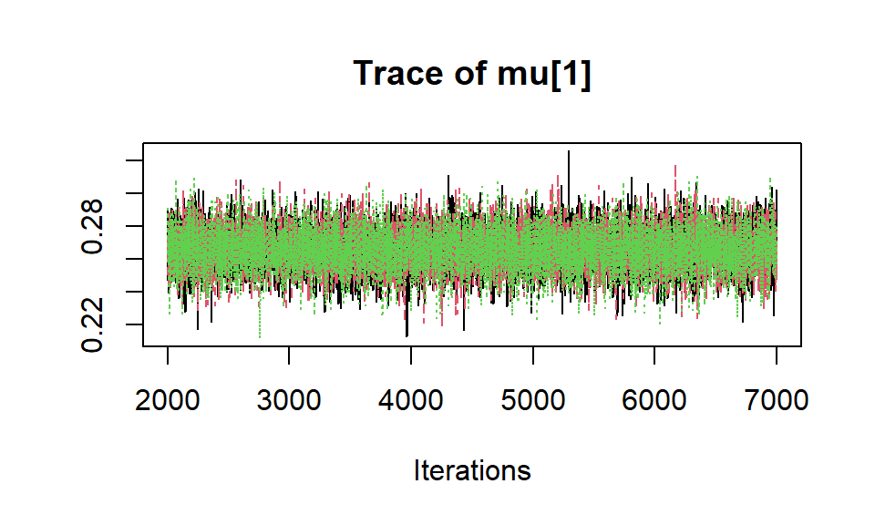

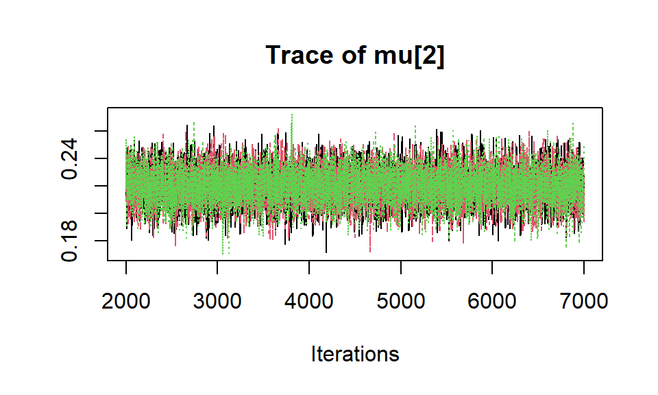

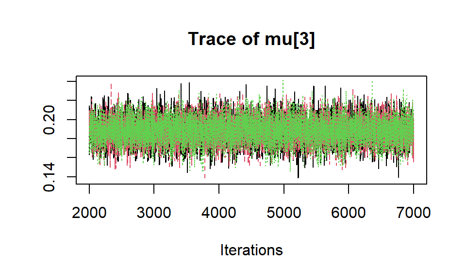

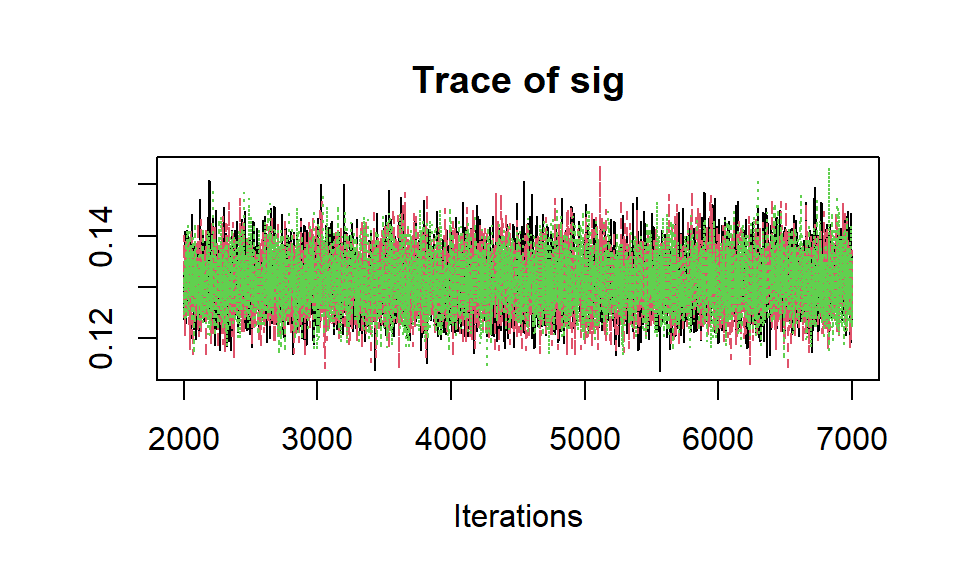

```r
# plot chains
traceplot(mod_sim)
```

The chains look to have converged well and don’t look auto correlated. Let’s run some diagnosics to be sure:

```r
gelman.diag(mod_sim)
```

```
## Potential scale reduction factors:
##
##       Point est. Upper C.I.
## mu[1]          1          1
## mu[2]          1          1
## mu[3]          1          1
## sig            1          1
##
## Multivariate psrf
##
## 1
```

```r
autocorr.diag(mod_sim)
```

```
##               mu[1]        mu[2]         mu[3]          sig
## Lag 0   1.000000000  1.000000000  1.0000000000  1.000000000
## Lag 1   0.008736791  0.005900327  0.0051032549 -0.003291980
## Lag 5   0.007781663 -0.007348007  0.0079066091  0.001524433
## Lag 10 -0.018556925  0.002634372 -0.0022556957  0.005985246
## Lag 50 -0.009655594 -0.011368444  0.0006050338  0.006735623
```

```r
cat('\n Effective sample sizes:\n')
```

```
##
##  Effective sample sizes:
```

```r
effectiveSize(mod_sim)
```

```
##    mu[1]    mu[2]    mu[3]      sig
## 15215.73 14576.72 15216.47 14788.45
```

The Gelman statistics for all of our parameters are 1, suggesting the model has converged. The chains are not autocorrelated, suggesting we’ve thinned them enough, and the effective sample sizes are very close to the true sample size of 3 chains * 5000 samples = 15000. Thus, there are no major issues with our model fitting.

Finally, lets look at the residuals to evaluate if there are any obvious problems with the model choice:

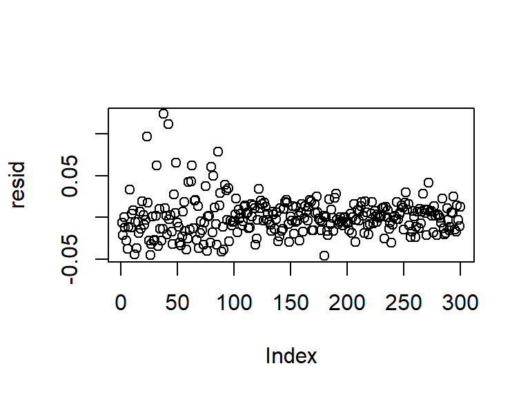

```r
# calculate parameter means
pm_params = colMeans(mod_csim)
yhat = pm_params[1:3][data_jags$grp]

# calculate reisduals
resid = data_jags$y - yhat

# plot the residuals
plot(resid)
```

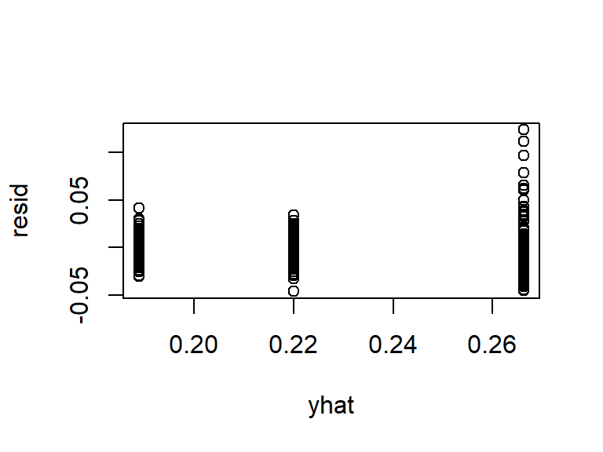

```r
plot(yhat, resid) # need to allow different variances across groups.
```

The residuals seem a little correlated with index, which is why we fit a more complex model which included individual variance for each group. However, ultimately, this did not meaningfully improve the model fit, so we have kept this simpler model.

Now that we’re satisfied that our model has fit the data well, lets plot the posterior distributions over mean training effect for each group.

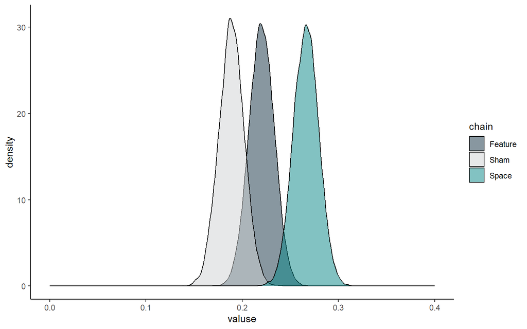

```r
darkteal = rgb(18 / 255, 47 / 255, 65 / 255)
medteal = rgb(5 / 255, 133 / 255, 134 / 255)
grey = rgb(208 / 255, 210 / 255, 211 / 255)

#Sample data
datplot <- data.frame(valuse = c(mod_csim[,1],mod_csim[,2],mod_csim[,3]), chain = c(rep("Space", 15000), rep("Feature", 15000), rep("Sham", 15000)))
#Plot.
plt=ggplot(datplot, aes(x = valuse, fill = chain)) + geom_density(alpha = 0.5)+ scale_fill_manual( values = c(darkteal, grey,medteal))
plt+ xlim(0,0.4) + theme_classic()
```

It’s clear that the representational dissimilarity across test days differed by neurofeedback type, but there is still some overlap. Lets use these to compute some meaningful statistics.

```
## HPD interval by parameter:
```

```
##           lower     upper
## mu[1] 0.2410015 0.2921490
## mu[2] 0.1951816 0.2462925
## mu[3] 0.1628887 0.2145902
## sig   0.1205639 0.1411955
## attr(,"Probability")
## [1] 0.95
```

```
## Posterior likelihood that Space training shifts representation more than sham:
```

```
## [1] 1
```

```
## Posterior likelihood that Feature training shifts representation  more than sham:
```

```
## [1] 0.954
```

This represents compelling evidence that neurofeedback training is likely to lead to larger shifts in the neural representation of the attention task than sham neurofeedback. This effect is decisive for the space neurofeedback group. For the feature neurofeedback group, 95% of new samples from the population are likely to have a larger mean behavioural training effect for neurofeedback than for sham feedback.

### Steady State Visual Evoked Potentials (SSVEPs) - Following up on training efficacy

#### Methodological background

The RSA analysis revealed that Neurofeedback influenced the multivariate pattern of neural activity with which participants represented the task. One candidate shift in neural activity which could contribute to this effect would be a change in the amplitude of the SSVEP attentional selectivity affect.

In the attention task used for this experiment, visual stimuli for each of the unique combinations of features and spatial locations flickered at unique frequencies (e.g. white dots might flicker at 8 Hz in one spatial location and 12 Hz at another spatial location). Flickering visual stimuli such as this evoke rhythmic responses in participants’ visual cortices, which can be recorded with EEG. These “steady-state visual evoked potentials” (SSVEPs) vary in strength with attention, such that attended visual information evokes stronger SSVEPs than unattended visual information. We hypothesised that the strength of this “attentional selectivity” affect might change after neurofeedback training.

Sanity checks of the data revealed that SSVEPs were present at all flicker frequencies for all training groups (Figure 2a), and that the topological distribution of these SSVEPs was similar across all training groups (Figure 2b).

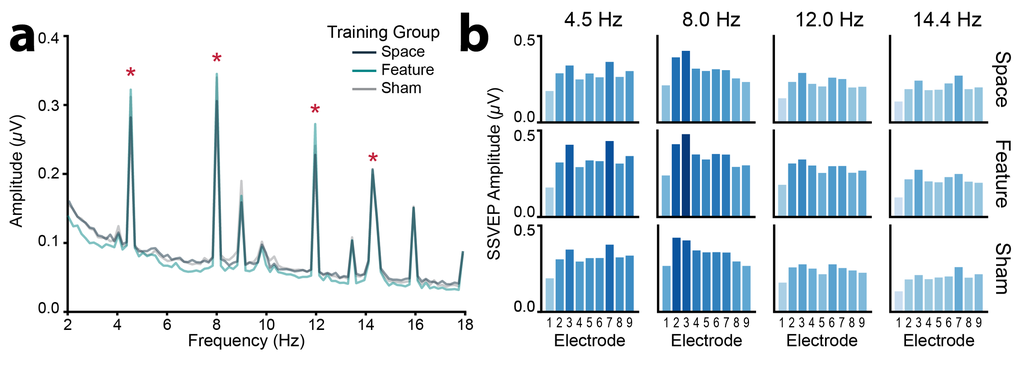

Frequency tagging results

**Figure 2. Frequency tagging results.** a.) Frequency spectrums. (**a**) Frequency spectra generated by submitting the average trial ERP for each neurofeedback group (Space, Feature, Sham) to FFTs (averaged across all recorded electrodes). SSVEPs at the fundamental flicker frequencies (f<sub>0</sub><sup>1</sup> = 4.5 Hz, f<sub>0</sub><sup>2</sup>= 8.0 Hz, f<sub>0</sub><sup>3</sup>= 12.0 Hz, f<sub>0</sub><sup>4</sup> = 14.4 Hz) are marked by red asterisks. (**b**) Bar plots showing SSVEP amplitudes at each electrode (1: Iz, 2: Oz, 3: POz, 4: O1, 5: O2, 6: PO3, 7: PO4 8: PO7, 9: PO8) for each flicker frequency (4.5 Hz, 8.0 Hz, 12.0 Hz, 14.4 Hz) across the three neurofeedback groups (Space, Feature, Sham).

#### Load Data

We begin by loading in the SSVEP results. These data show the SSVEP amplitudes for attended (cued) and unattended (uncued) stimuli, as well as attentional selectivity (attended - unattend SSVEP) from before to after neurofeedback training for each neurofeedback group (Space, Feature, Sham).

We’ll also add a new factor (“NFTraining”) with two just two levels (Neurofeedback, Sham), so that we have the option to evaluate the effect of getting active neurofeedback , regardless of what type of attention the feedback represented.

```r
# load data
SSVEPdata = read.csv("//data.qbi.uq.edu.au/VISATTNNF-Q1357/Results/CompareSpaceFeat/group/motiondiscrim_SelectivityResults_ALL.csv")

# Account for formatting issues when saving out pandas dataframe.
colnames(SSVEPdata)[5] ="SSVEPSelectivity"

# factorise existing factors
SSVEPdata$Attention.Trained = factor(SSVEPdata$Attention.Trained, levels=c("Space", "Feature", "Sham"))
SSVEPdata$Attention.Type = factor(SSVEPdata$Attention.Type, levels=c("Space", "Feature"))
SSVEPdata$Testday = factor(SSVEPdata$Testday, levels=c( "pre-training", "post-training"))

# edit stored sham condition Subjectids to be unique
SSVEPdata[SSVEPdata$Attention.Trained=="Sham",]$SubID = SSVEPdata[SSVEPdata$Attention.Trained=="Sham",]$SubID + 1000
SSVEPdata$SubID = factor(SSVEPdata$SubID)

# Create NFTraining factor
SSVEPdata$NFTraining = SSVEPdata$Attention.Trained
levels(SSVEPdata$NFTraining) = c( "Neurofeedback","Neurofeedback", "Sham")

# Show table data in markdown output
data <- SSVEPdata[1:10, ]
knitr::kable(data, caption = "Sample of SSVEP Data")
```

Sample of SSVEP Data

| SubID | Testday | Attention.Type | Attention.Trained | SSVEPSelectivity | SSVEPs_attd | SSVEPs_unattd | SSVEPs_var | NFTraining |
| --- | --- | --- | --- | --- | --- | --- | --- | --- |
| 10 | pre-training | Space | Space | -0.0165308 | 0.6990369 | 0.7155677 | 0.1017662 | Neurofeedback |
| 10 | pre-training | Feature | Space | -0.0049595 | 0.6730521 | 0.6780117 | 0.0308502 | Neurofeedback |
| 10 | post-training | Space | Space | -0.0701180 | 0.6773518 | 0.7474698 | -0.0564231 | Neurofeedback |
| 10 | post-training | Feature | Space | -0.0630475 | 0.6340778 | 0.6971252 | 0.0213273 | Neurofeedback |
| 11 | pre-training | Space | Space | 0.1095530 | 0.3090604 | 0.1995074 | 0.0845626 | Neurofeedback |
| 11 | pre-training | Feature | Space | 0.0273538 | 0.2546663 | 0.2273124 | 0.0208669 | Neurofeedback |
| 11 | post-training | Space | Space | 0.2500547 | 0.4192717 | 0.1692170 | 0.1440604 | Neurofeedback |
| 11 | post-training | Feature | Space | 0.1076970 | 0.3082577 | 0.2005607 | 0.0386452 | Neurofeedback |
| 19 | pre-training | Space | Space | 0.1732176 | 0.2348893 | 0.0616717 | 0.0675695 | Neurofeedback |
| 19 | pre-training | Feature | Space | 0.0441433 | 0.1507140 | 0.1065707 | 0.0103112 | Neurofeedback |

The key effect we’re interested in is whether attentional selectivity changes from pre-training to post-training, so we’ll calculate this difference for each of our participants and conditions.

```r
## Preallocate
SSVEPdata_train = SSVEPdata[SSVEPdata$Testday=="pre-training",]

## Calculate training effects
SSVEPdata_train$SSVEP_TrEfct = SSVEPdata[SSVEPdata$Testday=="post-training",]$SSVEPSelectivity - SSVEPdata[SSVEPdata$Testday=="pre-training",]$SSVEPSelectivity
```

#### Sanity check: Attention Selectivity

Before we proceed with evaluating whether attentional selectivity changed over time, we need to confirm that all groups of participants did show attentional selectivity (i.e. stronger SSVEPs to attended information than unattended information).

We’ll start by defining a function that extracts the data for each of our conditions of interest from the big data frame.

```r
getdata <- function(SSVEPdata, attntrained) {
  # get data for this condition
  # data <- SSVEPdata[SSVEPdata['Attention.Type']==attntype,]
  data <- SSVEPdata[SSVEPdata['Attention.Trained']==attntrained,]

  # Average across test days
  data <- data %>% group_by(SubID) %>% summarise(M_attd=mean(SSVEPs_attd), M_unattd=mean(SSVEPs_unattd)) %>% as.data.frame()

  # pivot so that attention condition (attended, unattended) can be used for t-test
  data <-pivot_longer(data, cols=c(M_attd, M_unattd), names_to="attncond", values_to ='SSVEPamp')%>% as.data.frame()

  # return data
  return(data)
}
```

Now lets run our tests:

```
##
## Training Group:  Space
```

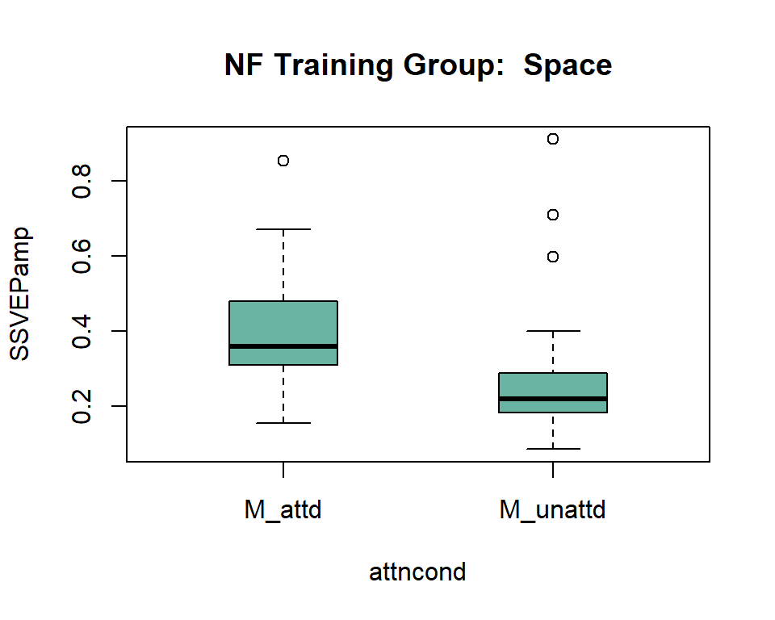

```
## Bayes factor analysis
## --------------
## [1] Alt., r=0.707 : 14.55047 ±0%
##
## Against denominator:
##   Null, mu1-mu2 = 0
## ---
## Bayes factor type: BFindepSample, JZS
##
##
## Training Group:  Feature
```

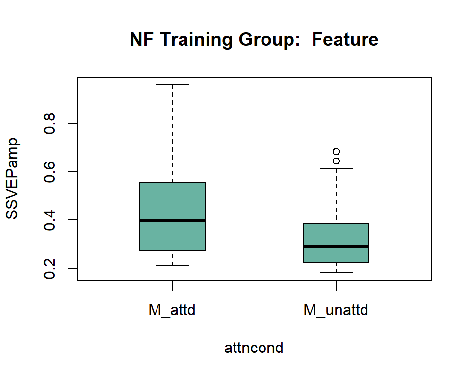

```
## Bayes factor analysis
## --------------
## [1] Alt., r=0.707 : 7.511203 ±0%
##
## Against denominator:
##   Null, mu1-mu2 = 0
## ---
## Bayes factor type: BFindepSample, JZS
##
##
## Training Group:  Sham
```

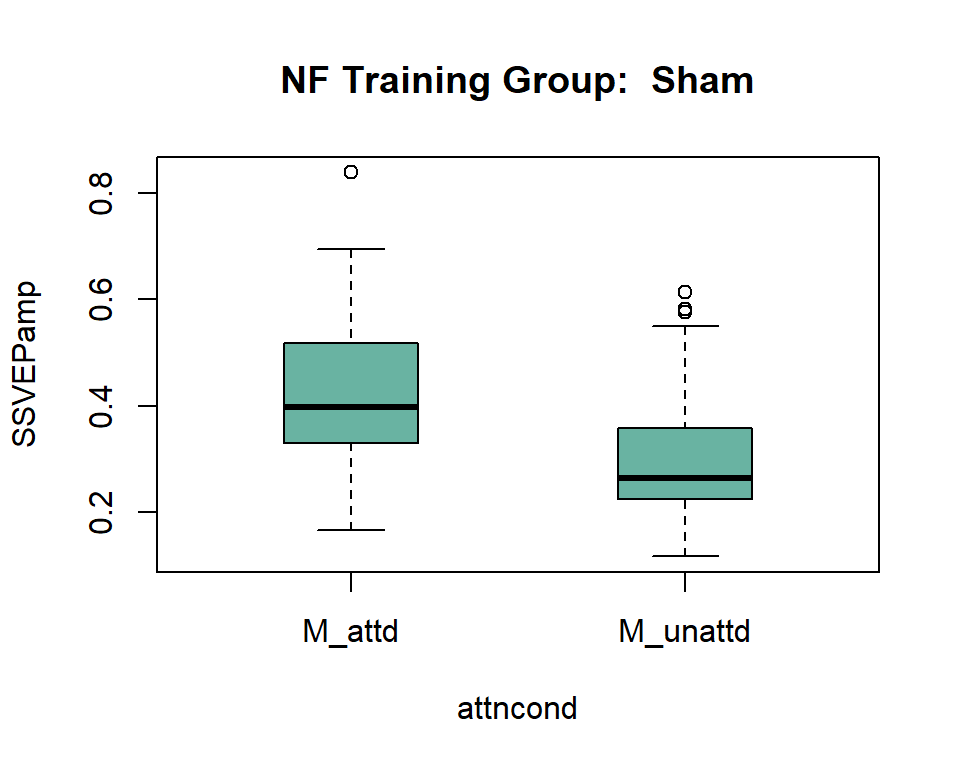

```
## Bayes factor analysis
## --------------
## [1] Alt., r=0.707 : 94.3579 ±0%
##
## Against denominator:
##   Null, mu1-mu2 = 0
## ---
## Bayes factor type: BFindepSample, JZS
```

```r
# for (attntype in c("Space", "Feature")){
for (attntrained in c("Space", "Feature", "Sham")){
  # display condition
  cat(paste('\nTraining Group: ', attntrained, '\n'))

  # get data
  data = getdata(SSVEPdata, attntrained)

  # visualise data
  boxplot(SSVEPamp ~ attncond, main=paste('NF Training Group: ', attntrained), col="#69b3a2", boxwex=0.4, data=data)

  # display result
  print(ttestBF(formula = SSVEPamp ~ attncond, data = data))

}
```

Thus, there is evidence that all training groups displayed the expected attentional selectivity effect.

#### SSVEP attentional selectivity training effects ANOVA

Having established that participants showed attentional selectivity effects overall, we can now assess whether this attentional selectivity changed between test-days, and whether any such changes interacted with the neurofeedback factor.

First, lets visualise the attentional selectivity data for each of our neurofeedback training groups, on each of the test days.

```r
# group data
data <- SSVEPdata %>% group_by(SubID, Testday, NFTraining) %>% summarise(SSVEPSelectivity=mean(SSVEPSelectivity)) %>% as.data.frame()
```

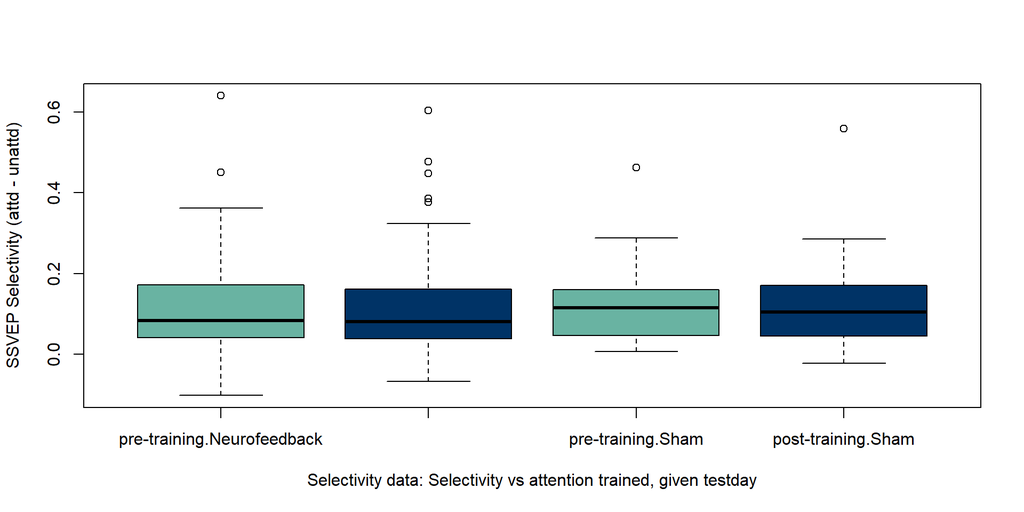

```r
# Plot
boxplot(SSVEPSelectivity ~ Testday*NFTraining  , data = data, col=c("#69b3a2","#003366"),
       xlab = "Selectivity data: Selectivity vs attention trained, given testday", ylab = "SSVEP Selectivity (attd - unattd)")
```

Here, we’re interested in whether there is a main effect of test day overall (aka, did attentional selectivity change from before to after training?) and whether any effects of test day interacted with the Neurofeedback training type that participants recieved.

```r
# group data
data <- SSVEPdata %>% group_by(SubID, Testday, NFTraining) %>% summarise(SSVEPSelectivity=mean(SSVEPSelectivity)) %>% as.data.frame()
# Run ANOVA
DisplayANOVAResults2X2(formula = SSVEPSelectivity ~ Testday * NFTraining  , data=data, maineffectstringA = "Test day:", maineffectstringB = "Neurofeedback training group:")
```

```
## Bayes factor analysis
## --------------
## [1] Testday                                   : 0.1493361   ±0.08%
## [2] NFTraining                                : 0.1580798   ±0.07%
## [3] Testday:NFTraining                        : 0.1566168   ±0.07%
## [4] Testday + NFTraining                      : 0.02289749  ±1.58%
## [5] Testday + Testday:NFTraining              : 0.0339014   ±2.79%
## [6] NFTraining + Testday:NFTraining           : 0.03194549  ±1.58%
## [7] Testday + NFTraining + Testday:NFTraining : 0.005387374 ±1.54%
##
## Against denominator:
##   Intercept only
## ---
## Bayes factor type: BFlinearModel, JZS
##
##
##
## Interaction:
##
## Bayes factor analysis
## --------------
## [1] Testday + NFTraining + Testday:NFTraining : 0.2352823 ±2.2%
##
## Against denominator:
##   SSVEPSelectivity ~ Testday + NFTraining
## ---
## Bayes factor type: BFlinearModel, JZS
##
##
##
##  Test day:
##
## Bayes factor analysis
## --------------
## [1] Testday + NFTraining + Testday:NFTraining : 0.158913 ±3.18%
##
## Against denominator:
##   SSVEPSelectivity ~ Testday + Testday:NFTraining
## ---
## Bayes factor type: BFlinearModel, JZS
##
##
##
##  Neurofeedback training group:
##
## Bayes factor analysis
## --------------
## [1] Testday + NFTraining + Testday:NFTraining : 0.1686427 ±2.2%
##
## Against denominator:
##   SSVEPSelectivity ~ NFTraining + Testday:NFTraining
## ---
## Bayes factor type: BFlinearModel, JZS
```

```r
dat = SSVEPdata_train  %>% group_by(NFTraining)
dat = dat %>% summarise(M=mean(SSVEP_TrEfct), SD=sd(SSVEP_TrEfct)) %>% as.data.frame()

# Show table data in markdown output
knitr::kable(dat, caption = "SSVEP Selectivity training effect (Post training - Pre training")
```

SSVEP Selectivity training effect (Post training - Pre training

| NFTraining | M | SD |
| --- | --- | --- |
| Neurofeedback | -0.0026885 | 0.0920329 |
| Sham | 0.0104992 | 0.1062743 |

#### MCMC Gibbs Sampling

To get a more intuitive understanding of this result, we’ll use an MCMC Gibbs sampling approach to estimate the likely distributions of training effects for each type of neurofeedback in the population.

We’ll begin by setting up Gibbs sampling models using rjags (just another gibbs sampler). We’ll compare two different models. A simple model in which we allow the mean to differ across groups, but use a common variance, and a more complicated model with unique variances for each group. We’ll compute both and evaluate which fits best (penalising for model complexity).

```r
# set model strings for how model parameters will be updated on each iteration. Model means will be sampled from a normal distribution, and precision will be sampled from a gamma distribution

# Simpler model
mod_string1 = " model {
    for (i in 1:length(y)) {
        y[i] ~ dnorm(mu[grp[i]], prec)
    }

    for (j in 1:3) {
        mu[j] ~ dnorm(0.0, 1.0/1.0e6)
    }

    prec ~ dgamma(5/2.0, 5*1.0/2.0)
    sig = sqrt( 1.0 / prec )
} "

# more complex model

mod_string2 = " model {
    for (i in 1:length(y)) {
        y[i] ~ dnorm(mu[grp[i]], prec[grp[i]])
    }

    for (j in 1:3) {
        mu[j] ~ dnorm(0.0, 1.0/1.0e6)
        prec[j] ~ dgamma(5/2.0, 5*1.0/2.0)

    }
    sig = sqrt( 1.0 / prec )
} "


# set and initialise the model parameters with broad, non-informative priors.
params = c("mu", "sig")
inits1 = function() {
  inits = list("mu"=rnorm(3,0.0,100.0), "prec"=rgamma(1,1.0,1.0))
}

inits2 = function() {
  inits = list("mu"=rnorm(3,0.0,100.0), "prec"=rgamma(3,1.0,1.0))
}

# the data we'll use - in this case the training effects for sensitivity.
data_jags = list(y=SSVEPdata_train$SSVEP_TrEfct,
                 grp=as.numeric(SSVEPdata_train$Attention.Trained))


# Pass the parameters and models to jags.
#simpler model
mod1 = jags.model(textConnection(mod_string1), data=data_jags, inits=inits1, n.chains=3)
#more complex model
mod2 = jags.model(textConnection(mod_string2), data=data_jags, inits=inits2, n.chains=3)
```

Next, lets evaluate the fit on each of these two models. For this, we’ll use the Deviance Information Criterion (DIC).

```r
# update model 1000 times
update(mod1, 1e3)
update(mod2, 1e3)

# compute the DIC - the smaller the dic the better the fit
cat("simpler model DIC:")
```

```
## simpler model DIC:
```

```r
(dic1=dic.samples(mod1, n.iter=1e3))
```

```
## Mean deviance:  -278.5
## penalty 4.047
## Penalized deviance: -274.4
```

```r
cat("more complex model DIC:")
```

```
## more complex model DIC:
```

```r
(dic2=dic.samples(mod2, n.iter=1e3))
```

```
## Mean deviance:  -130.5
## penalty 6.039
## Penalized deviance: -124.4
```

```r
# Set the model
mod = mod1
```

It looks like model 1 has the better fit (when penalising for complexity). Next, we’ll run our simulation, using the winning model to sample from our 3 chains 5000 times each:

```r
# sample from model.
mod_sim = coda.samples(model=mod, variable.names=params, n.iter=5e3)
mod_csim = as.mcmc(do.call(rbind, mod_sim)) # combined chains

# display sample
summary(mod_sim)
```

```
##
## Iterations = 2001:7000
## Thinning interval = 1
## Number of chains = 3
## Sample size per chain = 5000
##
## 1. Empirical mean and standard deviation for each variable,
##    plus standard error of the mean:
##
##            Mean       SD  Naive SE Time-series SE
## mu[1]  0.003140 0.021917 1.790e-04      1.789e-04
## mu[2] -0.007827 0.020881 1.705e-04      1.716e-04
## mu[3]  0.010366 0.021086 1.722e-04      1.722e-04
## sig    0.179964 0.008663 7.074e-05      7.074e-05
##
## 2. Quantiles for each variable:
##
##           2.5%       25%       50%      75%   97.5%
## mu[1] -0.04016 -0.011500  0.003290 0.017746 0.04609
## mu[2] -0.04860 -0.021922 -0.007856 0.006373 0.03292
## mu[3] -0.03139 -0.003747  0.010285 0.024455 0.05207
## sig    0.16397  0.173967  0.179610 0.185657 0.19784
```

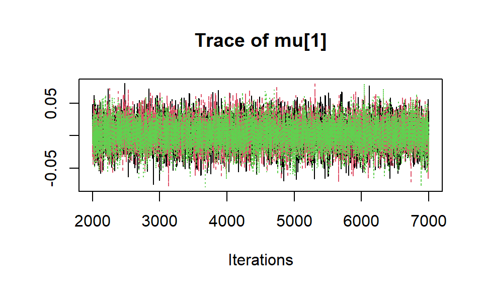

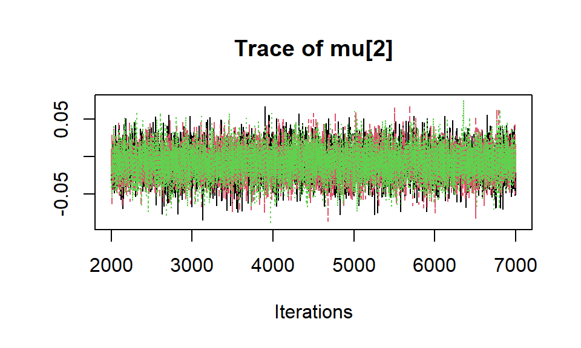

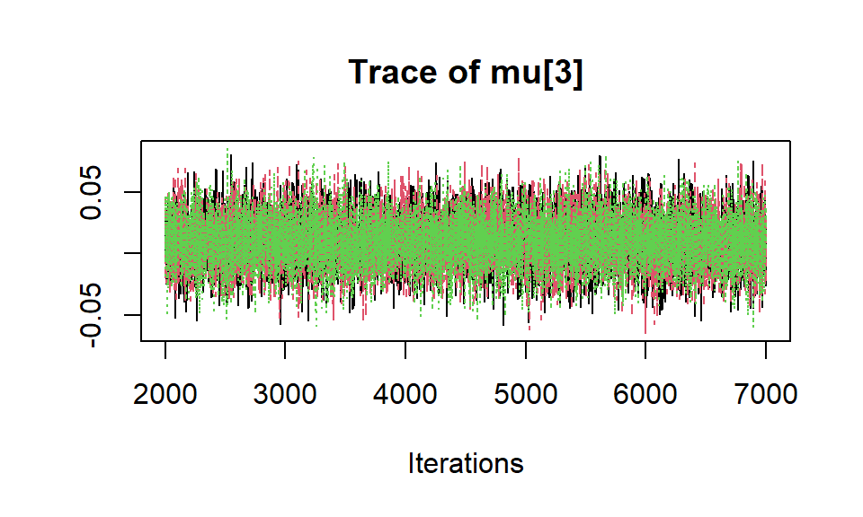

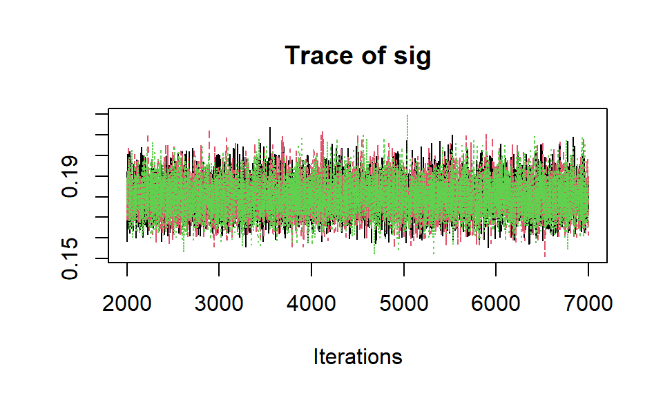

```r
# plot chains
traceplot(mod_sim)
```

The chains look to have converged well and don’t look auto correlated. Let’s run some diagnosics to be sure:

```r
gelman.diag(mod_sim)
```

```
## Potential scale reduction factors:
##
##       Point est. Upper C.I.
## mu[1]          1          1
## mu[2]          1          1
## mu[3]          1          1
## sig            1          1
##
## Multivariate psrf
##
## 1
```

```r
autocorr.diag(mod_sim)
```

```
##                mu[1]         mu[2]        mu[3]           sig
## Lag 0   1.0000000000  1.0000000000  1.000000000  1.0000000000
## Lag 1  -0.0077961754 -0.0040205345  0.005762864 -0.0006152239
## Lag 5   0.0018026067  0.0032565743 -0.008881767  0.0093204315
## Lag 10 -0.0036576390 -0.0000674597  0.003791289 -0.0095186175
## Lag 50  0.0002401558  0.0038669620  0.000328297 -0.0080872769
```

```r
cat('\n Effective sample sizes:\n')
```

```
##
##  Effective sample sizes:
```

```r
effectiveSize(mod_sim)
```

```
##    mu[1]    mu[2]    mu[3]      sig
## 15000.00 14813.88 15000.00 15000.00
```

The Gelman statistics for all of our parameters are 1, suggesting the model has converged. The chains are not autocorrelated, suggesting we’ve thinned them enough, and the effective sample sizes are very close to the true sample size of 3 chains * 5000 samples = 15000. Thus, there are no major issues with our model fitting.

Finally, lets look at the residuals to evaluate if there are any obvious problems with the model choice:

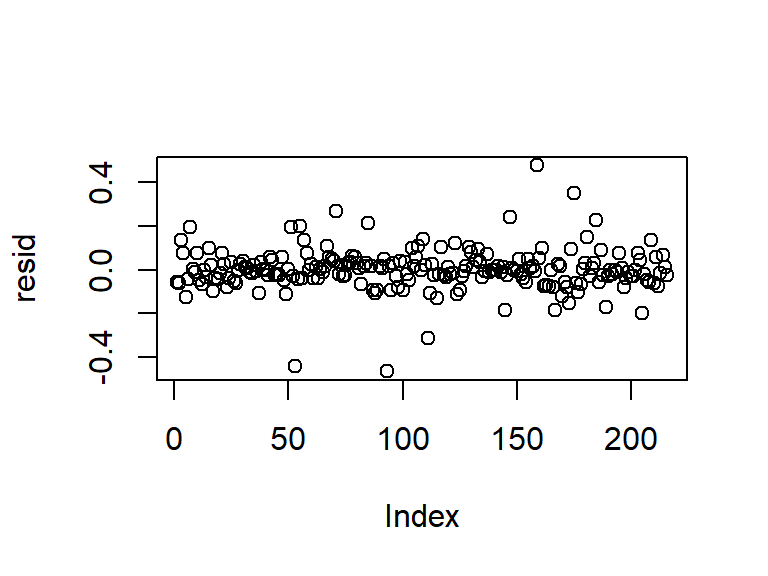

```r
# calculate parameter means
pm_params = colMeans(mod_csim)
yhat = pm_params[1:3][data_jags$grp]

# calculate reisduals
resid = data_jags$y - yhat

# plot the residuals
plot(resid)
```

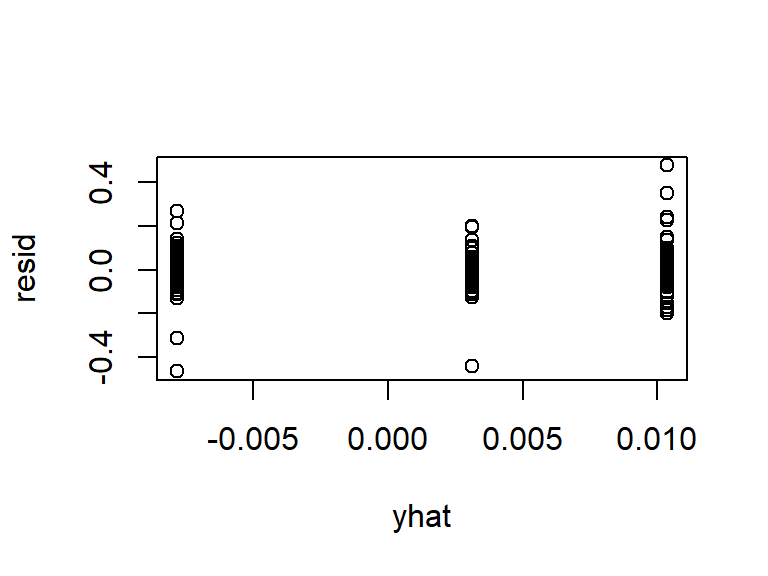

```r
plot(yhat, resid) # need to allow different variances across groups.
```

The residuals don’t look correlated with index, so there really don’t seem to be any issues with the fit.

Now that we’re satisfied that our model has fit the data well, lets plot the posterior distributions over mean training effect for each group.

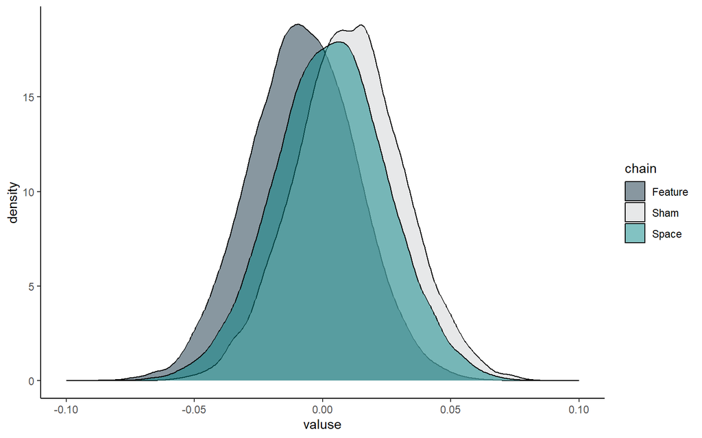

```r
darkteal = rgb(18 / 255, 47 / 255, 65 / 255)
medteal = rgb(5 / 255, 133 / 255, 134 / 255)
grey = rgb(208 / 255, 210 / 255, 211 / 255)

#Sample data
datplot <- data.frame(valuse = c(mod_csim[,1],mod_csim[,2],mod_csim[,3]), chain = c(rep("Space", 15000), rep("Feature", 15000), rep("Sham", 15000)))
#Plot.
plt=ggplot(datplot, aes(x = valuse, fill = chain)) + geom_density(alpha = 0.5)+ scale_fill_manual( values = c(darkteal, grey,medteal))
plt+ xlim(-0.1, 0.1) + theme_classic()
```

```r
ggsave("//data.qbi.uq.edu.au/VISATTNNF-Q1357/Results/CompareSpaceFeat/group/SSVEPtrain_Gibbsmeandensity.png")
ggsave("//data.qbi.uq.edu.au/VISATTNNF-Q1357/Results/CompareSpaceFeat/group/SSVEPtrain_Gibbsmeandensity.eps")
```

```
## HPD interval by parameter:
```

```
##             lower      upper
## mu[1] -0.03938493 0.04685816
## mu[2] -0.04868145 0.03273220
## mu[3] -0.02985472 0.05344286
## sig    0.16345121 0.19723361
## attr(,"Probability")
## [1] 0.95
```

```
## nPosterior likelihood that Space training increases SSVEP selectivity more than sham:
```

```
## [1] 0.4045333
```

```
## Posterior likelihood that Feature training increases SSVEP selectivity  more than sham:
```

```
## [1] 0.2662
```

### Behavioural Results Analysis - Evaluating Training efficacy

#### Methodological background

Before and after neurofeedback training, participants performed attention tests which involved monitoring fields of moving dots for target events, while ignoring distractor events. To evaluate participants to selectively attend to the cued targets in this task, we computed the sensitivity (*d’*) of their responses. Sensitivity is a measure of participants’ response selectivity, which describes how well they were able to identify targets and reject distractors. The method used to calculate sensitivity is described here:

Macmillan, N. A. (2002). Signal detection theory. *Stevens’ handbook of experimental psychology*, *4*, 43-90.

#### Load Data

We’ll start by loading in the behavioral data. We’ll load our data regarding participants performance across a number of measures, for each experimental condition.

```r
# load in data
behavedata = read.csv("//data.qbi.uq.edu.au/VISATTNNF-Q1357/Results/CompareSpaceFeat/group/motiondiscrim_behaveresults_HighClassificationAcc.csv")

# factorise existing factors
behavedata$Testday = factor(behavedata$Testday, levels=c( "Day 1", "Day 4"))
levels(behavedata$Testday) = c( "pre-training", "post-training")
behavedata$AttentionTrained = factor(behavedata$AttentionTrained, levels=c("Space", "Feature", "Sham"))
behavedata$Attention.Type = factor(behavedata$Attention.Type, levels=c("Space", "Feature"))
behavedata$SubID = factor(behavedata$SubID)

# Create new factor to describe the difference between NF and sham.
behavedata$NFTraining = behavedata$AttentionTrained
levels(behavedata$NFTraining) = c( "Neurofeedback","Neurofeedback", "Sham")

# Show table data in markdown output
data <- behavedata[1:10, ]
knitr::kable(data, caption = "Sample of Behavioural Data")
```

Sample of Behavioural Data

| SubID | ClassifierAccuracy | subID | subIDval | AttentionTrained | Attention.Type | Testday | Sensitivity | Criterion | correct | LikelihoodRatio | RT | RT_STD | InverseEfficiency | NFTraining |
| --- | --- | --- | --- | --- | --- | --- | --- | --- | --- | --- | --- | --- | --- | --- |
| Space10 | 58.97727 | 0 | 10 | Space | Space | pre-training | 0.4038833 | -0.7303410 | 29.86111 | NA | 0.9182817 | 0.1703654 | 3.0751758 | Neurofeedback |
| Space10 | 58.97727 | 0 | 10 | Space | Space | post-training | 2.1947275 | -0.4870691 | 72.91667 | NA | 0.8341931 | 0.1741730 | 1.1440363 | Neurofeedback |
| Space11 | 57.60870 | 1 | 11 | Space | Space | pre-training | 1.2274043 | -1.0254073 | 34.02778 | NA | 0.8113662 | 0.1601265 | 2.3844232 | Neurofeedback |
| Space11 | 57.60870 | 1 | 11 | Space | Space | post-training | 1.9641460 | -0.8599199 | 54.86111 | NA | 0.7246835 | 0.1499761 | 1.3209422 | Neurofeedback |
| Space19 | 65.73822 | 2 | 19 | Space | Space | pre-training | 1.0106391 | -0.6450298 | 44.44444 | NA | 0.7656250 | 0.1601028 | 1.7226562 | Neurofeedback |
| Space19 | 65.73822 | 2 | 19 | Space | Space | post-training | 1.6309329 | -0.5872069 | 59.02778 | NA | 0.7758987 | 0.1694555 | 1.3144637 | Neurofeedback |
| Space29 | 59.97252 | 5 | 29 | Space | Space | pre-training | 0.9731544 | -0.8052166 | 37.50000 | NA | 0.8899177 | 0.1770411 | 2.3731139 | Neurofeedback |
| Space29 | 59.97252 | 5 | 29 | Space | Space | post-training | 2.2425711 | -0.4898836 | 73.61111 | NA | 0.6319444 | 0.1468893 | 0.8584906 | Neurofeedback |
| Space43 | 65.15497 | 7 | 43 | Space | Space | pre-training | 0.8923011 | -1.1650186 | 23.61111 | NA | 0.8764297 | 0.1760210 | 3.7119377 | Neurofeedback |
| Space43 | 65.15497 | 7 | 43 | Space | Space | post-training | 2.1403075 | -1.2984133 | 40.97222 | NA | 0.7730697 | 0.1090753 | 1.8868141 | Neurofeedback |

The key effect we’re interested in is whether changes in sensitivity (d’) from pre-training to post-training depend on Neurofeedback training, so we’ll calculate this difference for each of our participants and conditions.

```r
## Preallocate
behavedata_train = behavedata[behavedata$Testday=="pre-training",]

## Calculate training effects
behavedata_train$Sensitivity_TrEfct = behavedata[behavedata$Testday=="post-training",]$Sensitivity - behavedata[behavedata$Testday=="pre-training",]$Sensitivity
```

#### Behavioural training effects ANOVA

First, lets visualise the attentional selectivity data for each of our neurofeedback training groups, on each of the test days.

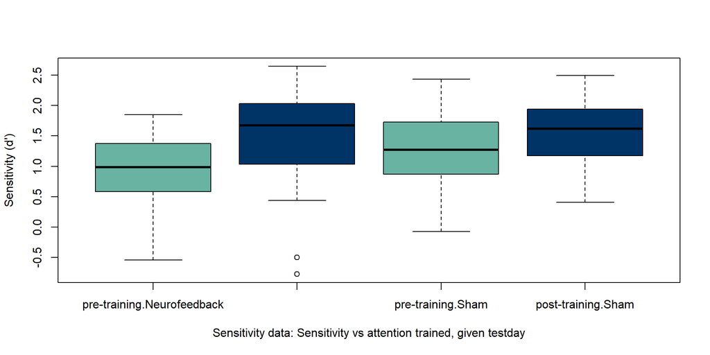

```r
# group data
data <- behavedata %>% group_by(SubID, Testday, NFTraining) %>% summarise(Sensitivity=mean(Sensitivity)) %>% as.data.frame()

# Plot
boxplot(Sensitivity ~ Testday*NFTraining , data = data, col=c("#69b3a2","#003366"), xlab = "Sensitivity data: Sensitivity vs attention trained, given testday", ylab = "Sensitivity (d')")
```

Here, we’re interested in whether there is a main effect of test day overall (aka, did sensitivity (d’) change from before to after training?) and whether any effects of test day interacted with the neurofeedback training type that participants recieved (active, sham).

```r
# group data
data <- behavedata %>% group_by(SubID, Testday, NFTraining) %>% summarise(Sensitivity=mean(Sensitivity)) %>% as.data.frame()
# tests
DisplayANOVAResults2X2(formula = Sensitivity ~ NFTraining*Testday + SubID, data=data, maineffectstringA = "Neurofeedback training group:", maineffectstringB = "Test day:")
```

```
## Bayes factor analysis
## --------------
## [1] Testday + SubID                                   : 338197152 ±0.9%
## [2] NFTraining + SubID                                : 0.7343607 ±1.76%
## [3] Testday:NFTraining + SubID                        : 97.83917  ±0.89%
## [4] Testday + NFTraining + SubID                      : 277330403 ±2.39%
## [5] Testday + Testday:NFTraining + SubID              : 587776970 ±1.82%
## [6] NFTraining + Testday:NFTraining + SubID           : 74.58621  ±1.94%
## [7] Testday + NFTraining + Testday:NFTraining + SubID : 489022282 ±3.94%
##
## Against denominator:
##   Sensitivity ~ SubID
## ---
## Bayes factor type: BFlinearModel, JZS
##
##
##
## Interaction:
##
## Bayes factor analysis
## --------------
## [1] Testday + NFTraining + Testday:NFTraining + SubID : 1.76332 ±4.61%
##
## Against denominator:
##   Sensitivity ~ Testday + NFTraining + SubID
## ---
## Bayes factor type: BFlinearModel, JZS
##
##
##
##  Neurofeedback training group:
##
## Bayes factor analysis
## --------------
## [1] Testday + NFTraining + Testday:NFTraining + SubID : 0.8319861 ±4.34%
##
## Against denominator:
##   Sensitivity ~ Testday + Testday:NFTraining + SubID
## ---
## Bayes factor type: BFlinearModel, JZS
##
##
##
##  Test day:
##
## Bayes factor analysis
## --------------
## [1] Testday + NFTraining + Testday:NFTraining + SubID : 6556470 ±4.4%
##
## Against denominator:
##   Sensitivity ~ NFTraining + Testday:NFTraining + SubID
## ---
## Bayes factor type: BFlinearModel, JZS
```

We find decisive evidence for a main effect of test day, so participants improved on the attention task with training, overall. There is also anecdotal evidence that behavioural training effects depend on the neurofeedback condition (active, sham). In the graph above, training effects appear to be larger for the active neurofeedback condition (compared to sham), so we will follow that up evaluating the strength of the evidence for this effect. First through, let’s export some summary statistics to help us report this result:

```r
# average
dat = behavedata  %>% group_by(NFTraining, Testday)
dat = dat %>% summarise(M=mean(Sensitivity), SD=sd(Sensitivity)) %>% as.data.frame()
# Show table data in markdown output
knitr::kable(dat, caption = "Sensitivity (d') training effect (Post training - Pre training")
```

Sensitivity (d’) training effect (Post training - Pre training

| NFTraining | Testday | M | SD |
| --- | --- | --- | --- |
| Neurofeedback | pre-training | 0.9839082 | 0.6797790 |
| Neurofeedback | post-training | 1.5331899 | 0.9338208 |
| Sham | pre-training | 1.2915791 | 0.8041745 |
| Sham | post-training | 1.6040503 | 0.8268501 |

#### Follow-up JZS t-tests

We found evidence that the effect of test day on behavioural performance interacted with neurofeedback. Let’s follow this up by directly investigating whether training effects differed across groups:

```r
# group data
data <- behavedata_train %>% group_by(SubID, NFTraining, Attention.Type) %>% summarise(Sensitivity_TrEfct=mean(Sensitivity_TrEfct)) %>% as.data.frame()

# run test
print(ttestBF(formula = Sensitivity_TrEfct ~ NFTraining , data = data))
```

```
## Bayes factor analysis
## --------------
## [1] Alt., r=0.707 : 3.036281 ±0.01%
##
## Against denominator:
##   Null, mu1-mu2 = 0
## ---
## Bayes factor type: BFindepSample, JZS
```

Thus, we find substantial evidence that participants receiving active neurofeedback improved more than participants receiving sham neurofeedback. Let’s break this down by type of active neurofeedback:

```r
# group data
data <- behavedata_train %>% group_by(SubID, AttentionTrained, Attention.Type) %>% summarise(Sensitivity_TrEfct=mean(Sensitivity_TrEfct)) %>% as.data.frame()

# run test Space
cat("Space Vs. Sham\n")
```

```
## Space Vs. Sham
```

```r
tmpdat = data[data$AttentionTrained %in% c("Space" ,"Sham"),]
tmpdat$AttentionTrained = factor(tmpdat$AttentionTrained)
print(ttestBF(formula = Sensitivity_TrEfct ~ AttentionTrained, data = tmpdat))
```

```
## Bayes factor analysis
## --------------
## [1] Alt., r=0.707 : 1.920131 ±0.01%
##
## Against denominator:
##   Null, mu1-mu2 = 0
## ---
## Bayes factor type: BFindepSample, JZS
```

```r
# run test Feature
cat("Feature Vs. Sham\n")
```

```
## Feature Vs. Sham
```

```r
tmpdat = data[data$AttentionTrained %in% c("Feature" ,"Sham"),]
tmpdat$AttentionTrained = factor(tmpdat$AttentionTrained)
print(ttestBF(formula = Sensitivity_TrEfct ~ AttentionTrained, data = tmpdat))
```

```
## Bayes factor analysis
## --------------
## [1] Alt., r=0.707 : 1.908234 ±0.01%
##
## Against denominator:
##   Null, mu1-mu2 = 0
## ---
## Bayes factor type: BFindepSample, JZS
```

Thus, we find anecdotal evidence that both the space and feature neurofeedback groups improved more on the attention task overall than participants who recieved sham neurofeedback. Let’s export some summary statistics to help report these results:

```r
# average
dat = behavedata_train  %>% group_by(AttentionTrained)
dat = dat %>% summarise(M=mean(Sensitivity_TrEfct), SD=sd(Sensitivity_TrEfct)) %>% as.data.frame()

# Show table data in markdown output
knitr::kable(dat, caption = "SSVEP Selectivity training effect (Post training - Pre training")
```

| AttentionTrained | M | SD |
| --- | --- | --- |
| Space | 0.5557986 | 0.5272538 |
| Feature | 0.5422060 | 0.4712876 |
| Sham | 0.3124712 | 0.3964433 |

```r
# average based on NFtraining
dat = behavedata_train  %>% group_by(NFTraining)
dat = dat %>% summarise(M=mean(Sensitivity_TrEfct), SD=sd(Sensitivity_TrEfct)) %>% as.data.frame()

# Show table data in markdown output
knitr::kable(dat, caption = "Sensitivity (d') training effect (Post training - Pre training")
```

Sensitivity (d’) training effect (Post training - Pre training

| NFTraining | M | SD |
| --- | --- | --- |
| Neurofeedback | 0.5492816 | 0.4977874 |
| Sham | 0.3124712 | 0.3964433 |

#### MCMC Gibbs Sampling

Overall, it looks as though receiving active neurofeedback was associated with larger training effects on the attention task than sham neurofeedback. Indeed we’re about 3 times more confident that neurofeedback has an effect than that it doesn’t. Is this a meaningful result? To get a more intuitive understanding of the scale of the effect of neurofeedback, we’ll use an MCMC Gibbs sampling approach to estimate the likely distributions of training effects for each type of neurofeedbackin the population.

We’ll begin by setting up Gibbs sampling models using rjags (just another gibbs sampler). We’ll compare two different models. A simple model in which we allow the mean to differ across groups, but use a common variance, and a more complicated model with unique variances for each group. We’ll compute both and evaluate which fits best (penalising for model complexity).

```r
# set model strings for how model parameters will be updated on each iteration. Model means will be sampled from a normal distribution, and precision will be sampled from a gamma distribution

# Simpler model
mod_string1 = " model {
    for (i in 1:length(y)) {
        y[i] ~ dnorm(mu[grp[i]], prec)
    }

    for (j in 1:3) {
        mu[j] ~ dnorm(0.0, 1.0/1.0e6)
    }

    prec ~ dgamma(5/2.0, 5*1.0/2.0)
    sig = sqrt( 1.0 / prec )
} "

# more complex model

mod_string2 = " model {
    for (i in 1:length(y)) {
        y[i] ~ dnorm(mu[grp[i]], prec[grp[i]])
    }

    for (j in 1:3) {
        mu[j] ~ dnorm(0.0, 1.0/1.0e6)
        prec[j] ~ dgamma(5/2.0, 5*1.0/2.0)

    }
    sig = sqrt( 1.0 / prec )
} "


# set and initialise the model parameters with broad, non-informative priors.
params = c("mu", "sig")
inits1 = function() {
  inits = list("mu"=rnorm(3,0.0,100.0), "prec"=rgamma(1,1.0,1.0))
}

inits2 = function() {
  inits = list("mu"=rnorm(3,0.0,100.0), "prec"=rgamma(3,1.0,1.0))
}

# the data we'll use - in this case the training effects for sensitivity.
data_jags = list(y=behavedata_train$Sensitivity_TrEfct,
                 grp=as.numeric(behavedata_train$AttentionTrained))


# Pass the parameters and models to jags.
#simpler model
mod1 = jags.model(textConnection(mod_string1), data=data_jags, inits=inits1, n.chains=3)
#more complex model
mod2 = jags.model(textConnection(mod_string2), data=data_jags, inits=inits2, n.chains=3)
```

Next, lets evaluate the fit on each of these two models. For this, we’ll use the Deviance Information Criterion (DIC).

```r
# update model 1000 times
update(mod1, 1e3)
update(mod2, 1e3)

# compute the DIC - the smaller the dic the better the fit
cat("simpler model DIC:")
```

```
## simpler model DIC:
```

```r
(dic1=dic.samples(mod1, n.iter=1e3))
```

```
## Mean deviance:  145.9
## penalty 4.036
## Penalized deviance: 150
```

```r
cat("more complex model DIC:")
```

```
## more complex model DIC:
```

```r
(dic2=dic.samples(mod2, n.iter=1e3))
```

```
## Mean deviance:  151.4
## penalty 5.837
## Penalized deviance: 157.3
```

```r
# Set the model
mod = mod1
```

It looks like model 1 has the better fit (when penalising for complexity). Next, we’ll run our simulation, using the winning model to sample from our 3 chains 5000 times each:

```r
# sample from model.
mod_sim = coda.samples(model=mod, variable.names=params, n.iter=5e3)
mod_csim = as.mcmc(do.call(rbind, mod_sim)) # combined chains

# display sample
summary(mod_sim)
```

```
##
## Iterations = 2001:7000
## Thinning interval = 1
## Number of chains = 3
## Sample size per chain = 5000
##
## 1. Empirical mean and standard deviation for each variable,
##    plus standard error of the mean:
##
##         Mean      SD  Naive SE Time-series SE
## mu[1] 0.5558 0.08231 0.0006720      0.0006633
## mu[2] 0.5407 0.08565 0.0006994      0.0006994
## mu[3] 0.3126 0.08721 0.0007120      0.0007121
## sig   0.5096 0.03487 0.0002847      0.0002913
##
## 2. Quantiles for each variable:
##
##         2.5%    25%    50%    75%  97.5%
## mu[1] 0.3963 0.5000 0.5558 0.6099 0.7177
## mu[2] 0.3732 0.4834 0.5416 0.5988 0.7066
## mu[3] 0.1410 0.2540 0.3119 0.3697 0.4873
## sig   0.4473 0.4853 0.5075 0.5322 0.5836
```

It looks like on a whole, our model has recovered the means and standard deviations pretty well. Let’s plot the chains:

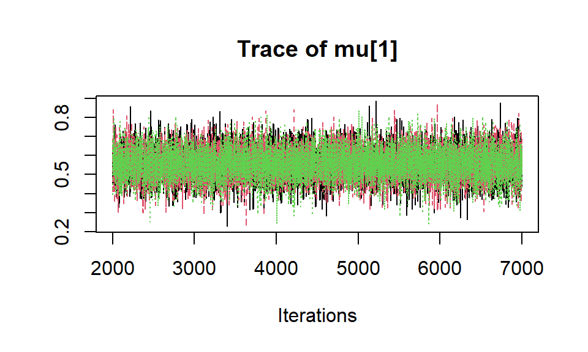

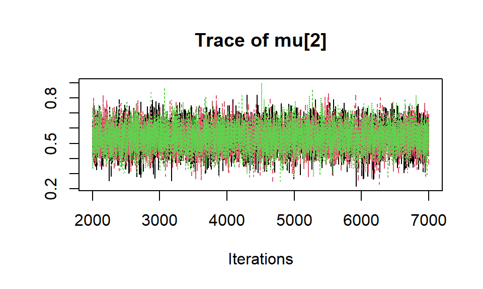

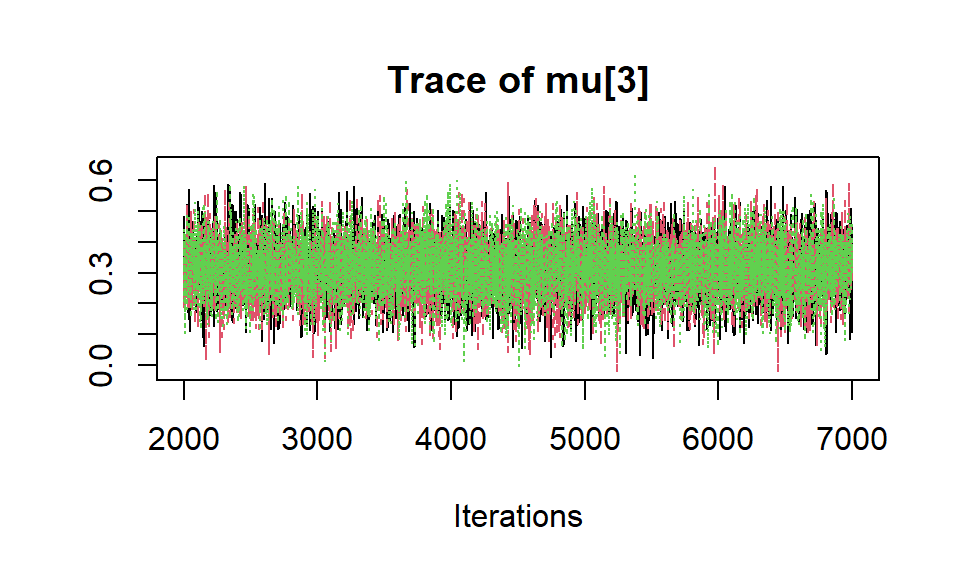

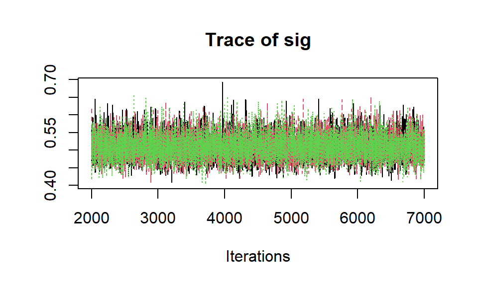

```r
# plot chains
traceplot(mod_sim)
```

The chains look to have converged well and don’t look auto correlated. Let’s run some diagnosics to be sure:

```r
gelman.diag(mod_sim)
```

```
## Potential scale reduction factors:
##
##       Point est. Upper C.I.
## mu[1]          1          1
## mu[2]          1          1
## mu[3]          1          1
## sig            1          1
##
## Multivariate psrf
##
## 1
```

```r
autocorr.diag(mod_sim)
```

```
##               mu[1]         mu[2]         mu[3]          sig
## Lag 0   1.000000000  1.0000000000  1.0000000000  1.000000000
## Lag 1  -0.009814611 -0.0040451095  0.0067792442  0.018461347
## Lag 5   0.003641484 -0.0008231446  0.0141998224 -0.002878727
## Lag 10  0.012257087 -0.0126019099 -0.0013019611  0.004272333
## Lag 50  0.001975942 -0.0084390416  0.0002810647  0.010106739
```

```r
cat('\n Effective sample sizes:\n')
```

```
##
##  Effective sample sizes:
```

```r
effectiveSize(mod_sim)
```

```
##    mu[1]    mu[2]    mu[3]      sig
## 15427.04 15000.00 15000.00 14344.38
```

The Gelman statistics for all of our parameters are 1, suggesting the model has converged. The chains are not autocorrelated, suggesting we’ve thinned them enough, and the effective sample sizes are very close to the true sample size of 3 chains * 5000 samples = 15000. Thus, there are no major issues with our model fitting.

Finally, lets look at the residuals to evaluate if there are any obvious problems with the model choice:

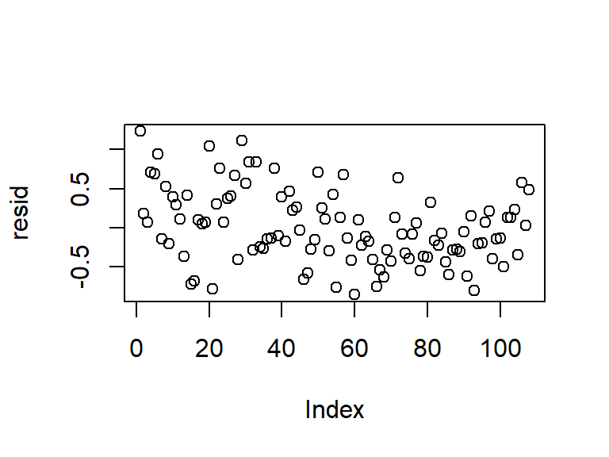

```r
# calculate parameter means
pm_params = colMeans(mod_csim)
yhat = pm_params[1:3][data_jags$grp]

# calculate reisduals
resid = data_jags$y - yhat

# plot the residuals
plot(resid)
```

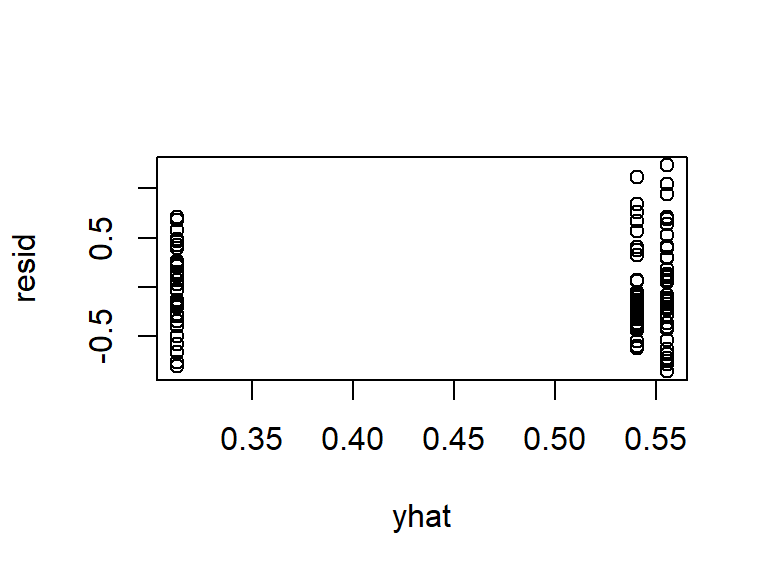

```r
plot(yhat, resid) # need to allow different variances across groups.
```

The residuals seem a little correlated with index, which is why we fit a more complex model which included individual variance for each group. However, ultimately, this did not meaningfully improve the model fit, so we have kept this simpler model.

Now that we’re satisfied that our model has fit the data well, lets plot the posterior distributions over mean training effect for each group.

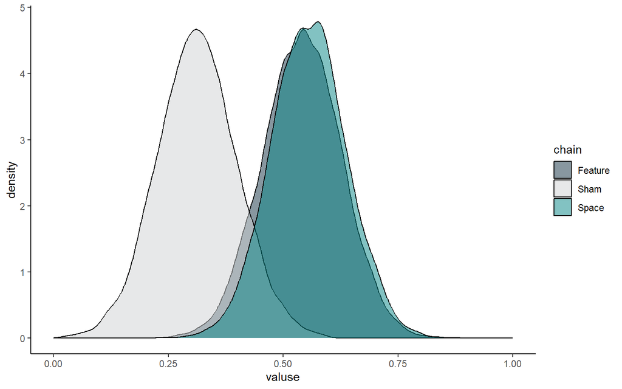

```r
darkteal = rgb(18 / 255, 47 / 255, 65 / 255)
medteal = rgb(5 / 255, 133 / 255, 134 / 255)
grey = rgb(208 / 255, 210 / 255, 211 / 255)

#Sample data
datplot <- data.frame(valuse = c(mod_csim[,1],mod_csim[,2],mod_csim[,3]), chain = c(rep("Space", 15000), rep("Feature", 15000), rep("Sham", 15000)))
#Plot.
plt=ggplot(datplot, aes(x = valuse, fill = chain)) + geom_density(alpha = 0.5)+ scale_fill_manual( values = c(darkteal, grey,medteal))
plt+ xlim(0,1) + theme_classic()
```

It’s clear that training effects are likely to be larger for space and feature training than sham, but there is still some overlap. Lets use these to compute some meaningful statistics.

```
## HPD interval by parameter:
```

```
##           lower     upper
## mu[1] 0.3999046 0.7208702
## mu[2] 0.3713033 0.7040145
## mu[3] 0.1438059 0.4896829
## sig   0.4439106 0.5788521
## attr(,"Probability")
## [1] 0.95
```

```
## nPosterior likelihood that Space training improves performance more than sham:
```

```
## [1] 0.9783333
```

```
## Posterior likelihood that Feature training improves performance more than sham:
```

```
## [1] 0.969
```

```
## Posterior likelihood that Space training improves performance by more than 50% more than sham :
```

```
## [1] 0.717
```

```
## Posterior likelihood that Feature training improves performance by more than 50% more than sham :
```

```
## [1] 0.6778667
```

This represents compelling evidence that neurofeedback training is likely to lead to larger increases in performance on the attention task than sham neurofeedback. To be precise, approximately 98% of samples of the population are likely to have a larger mean behavioural training effect for neurofeedback than for sham feedback.

## Evaluate Training Specificity

It was evident that active neurofeedback training resulted in a greater overall change in patterns of neural activity than sham. However, it is unclear from this finding alone whether the change was specific to the decoded cognitive function. We therefore next evaluated whether neural and behavioural measures of attention improved in a manner that was specific to the type of active neurofeedback (targetting spatial vs. feature-based attention) that participants received.

### Representational Similarity Analysis (RSA)

The RSA analysis above demonstrated that active neurofeedback groups shifted their task representation more than the sham neurofeedback group. We next asked whether these shifts in task representation were toward a more or less optimal state for spatial or feature-based attention.

To this end, we identified the two groups of participants who performed in the top tenth percentile (when averaging across all test days) when cued to excerpt spatial and feature-based attentional selection, respectively. We computed RDMs for each of these two groups (Space experts, feature-based experts), and then evaluated how similarly the remaining participants represented the task to these experts before vs. after neurofeedback training.

#### Load Data

We begin by loading in the RSA results for this analysis. These data show the bootstrapped representational dissimilarity data to experts at each cue type (space, feature) for each neurofeedback group (Space, Feature, Sham). Data represent a difference score from before to after neurofeedback training (i.e. similarity post-training - similarity pre-training)

We’ll add a new factor (“NFTraining”) with two just two levels (Neurofeedback, Sham), so that we have the option to evaluate the effect of getting active neurofeedback , regardless of what type of attention the feedback represented.

```r
# load data
RSAdata = read.csv("//data.qbi.uq.edu.au/VISATTNNF-Q1357/Results/CompareSpaceFeat/group/RSA_bybehave_results.csv")

# factorise existing factors
RSAdata$TrainingGroup = factor(RSAdata$TrainingGroup)
RSAdata$Cuetype = factor(RSAdata$Cuetype)

# Show table data in markdown output
data <- RSAdata[1:10, ]
knitr::kable(data, caption = "Sample of RSA Data")
```

Sample of RSA Data

| RDM_Score_effect | TrainingGroup | Cuetype |
| --- | --- | --- |
| -0.0177743 | Space | Space Task |
| -0.0523639 | Space | Space Task |
| -0.0578319 | Space | Space Task |
| -0.0941943 | Space | Space Task |
| -0.1725725 | Space | Space Task |
| -0.0648782 | Space | Space Task |
| -0.0884983 | Space | Space Task |
| -0.0624879 | Space | Space Task |
| -0.0732764 | Space | Space Task |
| -0.0290951 | Space | Space Task |

Let’s visualise these data before we test our hypotheses.

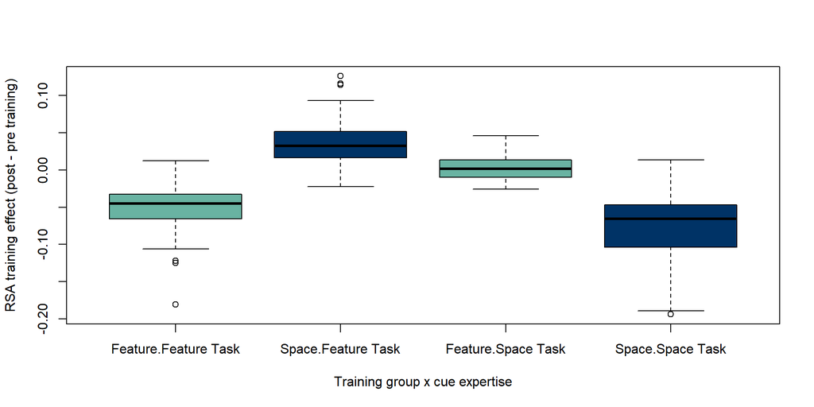

```r
# Plot
boxplot(RDM_Score_effect ~ TrainingGroup*Cuetype  , data = RSAdata, col=c("#69b3a2","#003366"),
       xlab = "Training group x cue expertise", ylab = "RSA training effect (post - pre training)")
```

#### Bayesian ANOVA

We’re curious about whether there was any interaction between the type of training participants received (space, feature) and the type of shift in task representation they shifted toward after training (space experts, feature experts). We therefore run a 2x2 Bayesian anova to evaluate the strength of evidence for an interaction between these two factors.

```r
# Run ANOVA
DisplayANOVAResults2X2(formula = RDM_Score_effect ~ TrainingGroup*Cuetype, data=RSAdata, maineffectstringA = "Training group:", maineffectstringB = "Cue expertise:")
```

```
## t is large; approximation invoked.
```

```
## Bayes factor analysis
## --------------
## [1] TrainingGroup                                   : 0.1322641    ±0.12%
## [2] Cuetype                                         : 268343.4     ±0%
## [3] TrainingGroup:Cuetype                           : 5.204836e+73 ±0%
## [4] TrainingGroup + Cuetype                         : 35471.4      ±0.96%
## [5] TrainingGroup + TrainingGroup:Cuetype           : 6.694767e+72 ±1.76%
## [6] Cuetype + TrainingGroup:Cuetype                 : 6.698614e+88 ±1.56%
## [7] TrainingGroup + Cuetype + TrainingGroup:Cuetype : 1.283191e+88 ±3.13%
##
## Against denominator:
##   Intercept only
## ---
## Bayes factor type: BFlinearModel, JZS
##
##
##
## Interaction:
##
## Bayes factor analysis
## --------------
## [1] TrainingGroup + Cuetype + TrainingGroup:Cuetype : 3.617537e+83 ±3.28%
##
## Against denominator:
##   RDM_Score_effect ~ TrainingGroup + Cuetype
## ---
## Bayes factor type: BFlinearModel, JZS
##
##
##
##  Training group:
##
## Bayes factor analysis
## --------------
## [1] TrainingGroup + Cuetype + TrainingGroup:Cuetype : 1.916708e+15 ±3.59%
##
## Against denominator:
##   RDM_Score_effect ~ TrainingGroup + TrainingGroup:Cuetype
## ---
## Bayes factor type: BFlinearModel, JZS
##
##
##
##  Cue expertise:
##
## Bayes factor analysis
## --------------
## [1] TrainingGroup + Cuetype + TrainingGroup:Cuetype : 0.1915607 ±3.5%
##
## Against denominator:
##   RDM_Score_effect ~ Cuetype + TrainingGroup:Cuetype
## ---
## Bayes factor type: BFlinearModel, JZS
```

We find decisive evidence for an interaction between neurofeedback training type (Space, Feature) and cue expertise (space, feature), suggesting that the direction of the shift in task representation depended on the type of active neurofeedback training that participants received.

#### Follow-up JZS t-tests

To follow up this interaction, let’s evaluate the effect of cue expertise separately for each of our active neurofeedback training groups, starting with space:

```r
# Space group
datuse = RSAdata[RSAdata$TrainingGroup == "Space",]
print(ttestBF(formula = RDM_Score_effect ~ Cuetype, data=datuse))
```

```
## t is large; approximation invoked.
```

```
## Bayes factor analysis
## --------------
## [1] Alt., r=0.707 : 1.480302e+48 ±0%
##
## Against denominator:
##   Null, mu1-mu2 = 0
## ---
## Bayes factor type: BFindepSample, JZS
```

```r
# print out result
dat = datuse   %>% group_by(Cuetype)
dat = dat %>% summarise(M=mean(RDM_Score_effect), SD=sd(RDM_Score_effect)) %>% as.data.frame()

# Show table data in markdown output
knitr::kable(dat, caption = "Space groups Representational dissimilarity to each group of experts")
```

Space groups Representational dissimilarity to each group of experts

| Cuetype | M | SD |
| --- | --- | --- |
| Feature Task | 0.0345518 | 0.0288652 |
| Space Task | -0.0763597 | 0.0446554 |

There is decisive evidence the active neurofeedback group trained on spatial attention shifted to represent the task more similarly to experts at the space cue, compared with experts on the feature cue.

How about the feature training group?

```r
# Feature group
datuse = RSAdata[RSAdata$TrainingGroup == "Feature",]
print(ttestBF(formula = RDM_Score_effect ~ Cuetype, data=datuse))
```

```
## t is large; approximation invoked.
```

```
## Bayes factor analysis
## --------------
## [1] Alt., r=0.707 : 3.850179e+32 ±0%
##
## Against denominator:
##   Null, mu1-mu2 = 0
## ---
## Bayes factor type: BFindepSample, JZS
```

```r
# print out result
dat = datuse   %>% group_by(Cuetype)
dat = dat %>% summarise(M=mean(RDM_Score_effect), SD=sd(RDM_Score_effect)) %>% as.data.frame()

# Show table data in markdown output
knitr::kable(dat, caption = "Feature groups Representational dissimilarity to each group of experts")
```

Feature groups Representational dissimilarity to each group of experts

| Cuetype | M | SD |
| --- | --- | --- |
| Feature Task | -0.0506021 | 0.0301102 |
| Space Task | 0.0022687 | 0.0159198 |

Here, there is decisive evidence the active neurofeedback group trained on feature-based attention shifted to represent the task more similarly to experts at the feature cue, compared with experts on the space cue.

Thus, it appears that there was a specific training effect, such that active neurofeedback training shifted the patterns of neural activity evoked by the attention task in a direction specifically associated with optimal performance on the trained cue-type.

#### MCMC Gibbs Sampling

To get a more intuitive understanding of the scale of this specific training effect, we’ll use an MCMC Gibbs sampling approach to estimate the likely distributions of the shift toward “congruent” (space training group toward space cue experts & feature training group toward feature cue experts) vs. “incongruent” (space training group toward feature cue experts & feature training group toward space cue experts) expert’s representations in the populations.

We’ll begin by setting up Gibbs sampling models using rjags. We’ll compare two different models. A simple model in which we allow the mean to differ across groups, but use a common variance, and a more complicated model with unique variances for each group. We’ll compute both and evaluate which fits best (penalising for model complexity).

let’s begin by organising the data to create the new congruency factor.

```r
# Rename levels of cue type factor so that they'll match the training group factor names
datause = RSAdata
levels(datause$Cuetype) = c("Feature", "Space")

# Define the congruence factor based on whether training group and cue type match
datause$trainingcongruence = factor(datause$TrainingGroup == datause$Cuetype)
levels(datause$trainingcongruence) = c("incongruent","congruent")
```

Let’s visualise these data to make sure they look as we’d expect from the result above:

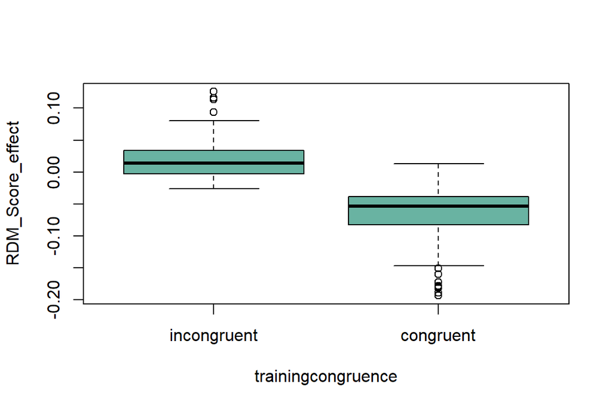

```r
boxplot(RDM_Score_effect ~ trainingcongruence, data=datause, col="#69b3a2")
```

Looks good! Let’s set up our models.

```r
# set model strings for how model parameters will be updated on each iteration. Model means will be sampled from a normal distribution, and precision will be sampled from a gamma distribution

# Simpler model
mod_string1 = " model {
    for (i in 1:length(y)) {
        y[i] ~ dnorm(mu[grp[i]], prec)
    }

    for (j in 1:2) {
        mu[j] ~ dnorm(0.0, 1.0/1.0e6)
    }

    prec ~ dgamma(5/2.0, 5*1.0/2.0)
    sig = sqrt( 1.0 / prec )
} "

# more complex model

mod_string2 = " model {
    for (i in 1:length(y)) {
        y[i] ~ dnorm(mu[grp[i]], prec[grp[i]])
    }

    for (j in 1:2) {
        mu[j] ~ dnorm(0.0, 1.0/1.0e6)
        prec[j] ~ dgamma(5/2.0, 5*1.0/2.0)

    }
    sig = sqrt( 1.0 / prec )
} "


# set and initialise the model parameters with broad, non-informative priors.
params = c("mu", "sig")
inits1 = function() {
  inits = list("mu"=rnorm(2,0.0,100.0), "prec"=rgamma(1,1.0,1.0))
}

inits2 = function() {
  inits = list("mu"=rnorm(2,0.0,100.0), "prec"=rgamma(2,1.0,1.0))
}

# the data we'll use - in this case the RDM Scores grouped by congruence.
data_jags = list(y=datause$RDM_Score_effect,
                 grp=as.numeric(datause$trainingcongruence))


# Pass the parameters and models to jags.
#simpler model
mod1 = jags.model(textConnection(mod_string1), data=data_jags, inits=inits1, n.chains=3)
#more complex model
mod2 = jags.model(textConnection(mod_string2), data=data_jags, inits=inits2, n.chains=3)
```

Next, let’s compare the fits of the two models:

```r
# update model 1000 times
update(mod1, 1e3)
update(mod2, 1e3)

# compute the DIC - the smaller the dic the better the fit
cat("simpler model DIC:")
```

```
## simpler model DIC:
```

```r
(dic1=dic.samples(mod1, n.iter=1e3))
```

```
## Mean deviance:  -946.1
## penalty 2.984
## Penalized deviance: -943.1
```

```r
cat("more complex model DIC:")
```

```
## more complex model DIC:
```

```r
(dic2=dic.samples(mod2, n.iter=1e3))
```

```
## Mean deviance:  -707.5
## penalty 4.069
## Penalized deviance: -703.4
```